# Applied Statistics

```python
#Total num people who planned to purchase : 500
#Total num people : 2000
probability = 500 / 2000
print(probability)
```

```
0.25
```

```python
#Num people that planned to purchase : 500
#Num people that planned to purchase and actually purchased : 400
joint_probability = 400 / 500
print(joint_probability)
```

```
0.8
```

## **Q2.** An electrical manufacturing company conducts quality checks at specified periods on the products it

## manufactures. Historically, the failure rate for the manufactured item is 5%. Suppose a random sample of 10

## manufactured items is selected. Answer the following questions.

```python
import numpy as np          #
import scipy.stats as stats # binomial distribution function

Range = np.arange(0, 11)
num_items = 10
rate = 0.05
binomial_dist = stats.binom.pmf(Range, num_items, rate)
```

**A.** Probability that none of the items are defective? [1 Mark]

```python
binomial_dist[0] #probability that the desired event occurred 0 times
```

```
0.5987369392383787
```

**B.** Probability that exactly one of the items is defective? [1 Mark]

```python
binomial_dist[1] #probability that the desired event occurred 1 time
```

```
0.3151247048623047
```

**C.** Probability that two or fewer of the items are defective? [1 Mark]

```python
binomial_dist[0] + binomial_dist[1] + binomial_dist[2] #probability that the desired event occurred 0 times + probability that the desired event occurred 1 times +  probability that the desired event occurred 2 times
```

```
0.988496442620703
```

**D.** Probability that three or more of the items are defective ? [1 Mark]

```python
1 - ( binomial_dist[0] + binomial_dist[1] + binomial_dist[2] )
```

```
0.01150355737929698
```

## **Q3.** A car salesman sells on an average 3 cars per week.

```python
import numpy as np               #
import scipy.stats as stats      # for poisson distribution function
import matplotlib.pyplot as plt  # for plotting graphs

num = 50                  # taking much higher than necessary number for plotting more accurate graph
Range = np.arange(0, num)
rate = 3                  # sells 3 cars per week

poisson_dist = stats.poisson.pmf(Range, rate)
```

**A.** What is Probability that in a given week he will sell some cars. [1 Mark]

```python
1 - poisson_dist[0] # 1 - probability of selling 0 cars
```

```
0.950212931632136
```

**B.** What is Probability that in a given week he will sell 2 or more but less than 5 cars. [1 Mark]

```python
poisson_dist[2] + poisson_dist[3] + poisson_dist[4] # probability that the desired event occurred 2 times + probability that the desired event occurred 3 times + probability that the desired event occurred 4 times
```

```
0.6161149710523164
```

**C.** Plot the poisson distribution function for cumulative probability of cars sold per-week vs number of cars sold per week. [1 Mark]

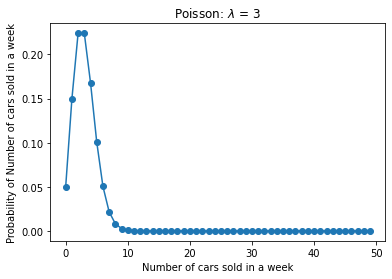

```python
plt.plot(Range, poisson_dist, 'o-')
plt.title('Poisson: $\lambda$ = %i ' % rate)
plt.xlabel('Number of cars sold in a week')
plt.ylabel('Probability of Number of cars sold in a week')
plt.show()
```

## Q4. Accuracy in understanding orders for a speech based bot at a restaurant is important for the Company X

## which has designed, marketed and launched the product for a contactless delivery due to the COVID-19

## pandemic. Recognition accuracy that measures the percentage of orders that are taken correctly is 86.8%.

## Suppose that you place an order with the bot and two friends of yours independently place orders with the

## same bot. Answer the following questions.

```python
import numpy as np          #
import scipy.stats as stats # binomial distribution function

Range = np.arange(0, 4)
num_orders = 3
rate = 0.868
binomial_dist = stats.binom.pmf(Range, num_items, rate)#supposed to be num_orsers, not num_items
```

**A.** What is the probability that all three orders will be recognised correctly? [1 Mark]

```python
prob = binomial_dist[3] #prob that desired event occurs 3 times
print(round(prob, 10))
print(prob, "(printing the whole value for consistency with other answers for this question)")
```

```
5.47971e-05
5.479714603862226e-05 (printing the whole value for consistency with other answers for this question)
```

**B.** What is the probability that none of the three orders will be recognised correctly?

```python
prob = binomial_dist[0] #prob that desired event occurs 0 times
print(round(prob, 10))
print(prob, "(printing the whole value for consistency with other answers for this question)")
```

```
1.6e-09
1.6059769660526557e-09 (printing the whole value for consistency with other answers for this question)
```

**C.** What is the probability that at least two of the three orders will be recognised correctly? [1 Mark]

```python
prob = binomial_dist[2] + binomial_dist[3]
print(round(prob, 10))
print(prob, "(printing the whole value for consistency with other answers for this question)")
```

```
5.79221e-05
5.792209849128563e-05 (printing the whole value for consistency with other answers for this question)
```

```python
#   binomial_dist[1] # wow, even the chances of getting just 1 order right are also so low??????
```

# Part 2

## _Steps and Tasks:__

## 1. Read the data set, clean the data and prepare final dataset to be used for analysis. [10 Marks]

```python
#import necessary packages

import numpy as np
import pandas as pd
import matplotlib.pyplot as plt
import seaborn as sns
from sklearn import linear_model
import statsmodels.api         as     sm
from statsmodels.formula.api import ols
```

```python
data_set = pd.read_csv("DS+-+Part2+-+Basketball.csv")
```

```python
data_set.head()
```

|  | Team | Tournament | Score | PlayedGames | WonGames | DrawnGames | LostGames | BasketScored | BasketGiven | TournamentChampion | Runner-up | TeamLaunch | HighestPositionHeld |
| --- | --- | --- | --- | --- | --- | --- | --- | --- | --- | --- | --- | --- | --- |
| 0 | Team 1 | 86 | 4385 | 2762 | 1647 | 552 | 563 | 5947 | 3140 | 33 | 23 | 1929 | 1 |
| 1 | Team 2 | 86 | 4262 | 2762 | 1581 | 573 | 608 | 5900 | 3114 | 25 | 25 | 1929 | 1 |
| 2 | Team 3 | 80 | 3442 | 2614 | 1241 | 598 | 775 | 4534 | 3309 | 10 | 8 | 1929 | 1 |
| 3 | Team 4 | 82 | 3386 | 2664 | 1187 | 616 | 861 | 4398 | 3469 | 6 | 6 | 1931to32 | 1 |
| 4 | Team 5 | 86 | 3368 | 2762 | 1209 | 633 | 920 | 4631 | 3700 | 8 | 7 | 1929 | 1 |

```python
data_set.describe(include="all")
```

|  | Team | Tournament | Score | PlayedGames | WonGames | DrawnGames | LostGames | BasketScored | BasketGiven | TournamentChampion | Runner-up | TeamLaunch | HighestPositionHeld |
| --- | --- | --- | --- | --- | --- | --- | --- | --- | --- | --- | --- | --- | --- |
| count | 61 | 61.000000 | 61 | 61 | 61 | 61 | 61 | 61 | 61 | 61 | 61 | 61 | 61.000000 |
| unique | 61 | NaN | 61 | 53 | 59 | 57 | 56 | 60 | 61 | 8 | 10 | 47 | NaN |
| top | Team 1 | NaN | 4385 | 2762 | 7 | 14 | 37 | 70 | 3140 | - | - | 1929 | NaN |
| freq | 1 | NaN | 1 | 3 | 2 | 2 | 3 | 2 | 1 | 52 | 48 | 10 | NaN |
| mean | NaN | 24.000000 | NaN | NaN | NaN | NaN | NaN | NaN | NaN | NaN | NaN | NaN | 7.081967 |
| std | NaN | 26.827225 | NaN | NaN | NaN | NaN | NaN | NaN | NaN | NaN | NaN | NaN | 5.276663 |
| min | NaN | 1.000000 | NaN | NaN | NaN | NaN | NaN | NaN | NaN | NaN | NaN | NaN | 1.000000 |
| 25% | NaN | 4.000000 | NaN | NaN | NaN | NaN | NaN | NaN | NaN | NaN | NaN | NaN | 3.000000 |
| 50% | NaN | 12.000000 | NaN | NaN | NaN | NaN | NaN | NaN | NaN | NaN | NaN | NaN | 6.000000 |
| 75% | NaN | 38.000000 | NaN | NaN | NaN | NaN | NaN | NaN | NaN | NaN | NaN | NaN | 10.000000 |
| max | NaN | 86.000000 | NaN | NaN | NaN | NaN | NaN | NaN | NaN | NaN | NaN | NaN | 20.000000 |

```python
data_set.info()
```

```
<class 'pandas.core.frame.DataFrame'>
RangeIndex: 61 entries, 0 to 60
Data columns (total 13 columns):
 #   Column               Non-Null Count  Dtype
---  ------               --------------  -----
 0   Team                 61 non-null     object
 1   Tournament           61 non-null     int64
 2   Score                61 non-null     object
 3   PlayedGames          61 non-null     object
 4   WonGames             61 non-null     object
 5   DrawnGames           61 non-null     object
 6   LostGames            61 non-null     object
 7   BasketScored         61 non-null     object
 8   BasketGiven          61 non-null     object
 9   TournamentChampion   61 non-null     object
 10  Runner-up            61 non-null     object
 11  TeamLaunch           61 non-null     object
 12  HighestPositionHeld  61 non-null     int64
dtypes: int64(2), object(11)
memory usage: 6.3+ KB
```

## Opening the file completely reveals that there are empty or invalid values in every field except Tournament and HighestPositionHeld, let's fix that :D

### Fixing TeamLaunch (Taking only first number in xxxx[to,-,_,~]xxxx

```python
cleaned_list = []
for data in data_set["TeamLaunch"]:
    cleaned_list.append(data.replace("to", " ").replace("-", " ").replace("_", " ").replace("~", " ").split(" ")[0])

data_set["TeamLaunch"] = cleaned_list
```

```python
data_set["TeamLaunch"]
```

```
0     1929
1     1929
2     1929
3     1931
4     1929
      ...
56    2009
57    1956
58    1951
59    1955
60    2017
Name: TeamLaunch, Length: 61, dtype: object
```

### Fixing Score (For this and all the remaining fields, set '-' to 0

```python
cleaned_list = []
for data in data_set["Score"]:
    cleaned_list.append(data.replace("-", "0"))
for index in range(0, len(cleaned_list)):
    cleaned_list[index] = int(cleaned_list[index])

data_set["Score"] = cleaned_list
data_set["Score"]
```

```
0     4385
1     4262
2     3442
3     3386
4     3368
      ...
56      34
57      22
58      19
59      14
60       0
Name: Score, Length: 61, dtype: int64
```

### Fixing PlayedGames

```python
cleaned_list = []
for data in data_set["PlayedGames"]:
    cleaned_list.append(data.replace("-", "0"))
for index in range(0, len(cleaned_list)):
    cleaned_list[index] = int(cleaned_list[index])

data_set["PlayedGames"] = cleaned_list
data_set["PlayedGames"]
```

```
0     2762
1     2762
2     2614
3     2664
4     2762
      ...
56      38
57      30
58      30
59      30
60       0
Name: PlayedGames, Length: 61, dtype: int64
```

```python
rem_columns = ["WonGames", "DrawnGames", "LostGames", "BasketScored", "BasketGiven", "TournamentChampion", "Runner-up"]

for field in rem_columns:
    cleaned_list = []
    for data in data_set[field]:
        cleaned_list.append(data.replace("-", "0"))
    for index in range(0, len(cleaned_list)):
        cleaned_list[index] = int(cleaned_list[index])
    data_set[field] = cleaned_list
```

```python
cleaned_list = []

for index in range(0, len(data_set["TeamLaunch"])):
    cleaned_list.append(int(data_set["TeamLaunch"][index]))
data_set["TeamLaunch"] = cleaned_list
```

## **2.** Perform detailed statistical analysis and EDA using univariate, bi-variate and multivariate EDA

## techniques to get data driven insights on recommending which teams they can approach

## which will be a deal win for them. Also as a data and statistics expert you have to develop a

## detailed performance report using this data. [10 Marks]

```python
data_set.info()
```

```
<class 'pandas.core.frame.DataFrame'>
RangeIndex: 61 entries, 0 to 60
Data columns (total 13 columns):
 #   Column               Non-Null Count  Dtype
---  ------               --------------  -----
 0   Team                 61 non-null     object
 1   Tournament           61 non-null     int64
 2   Score                61 non-null     int64
 3   PlayedGames          61 non-null     int64
 4   WonGames             61 non-null     int64
 5   DrawnGames           61 non-null     int64
 6   LostGames            61 non-null     int64
 7   BasketScored         61 non-null     int64
 8   BasketGiven          61 non-null     int64
 9   TournamentChampion   61 non-null     int64
 10  Runner-up            61 non-null     int64
 11  TeamLaunch           61 non-null     int64
 12  HighestPositionHeld  61 non-null     int64
dtypes: int64(12), object(1)
memory usage: 6.3+ KB
```

```
array([[<AxesSubplot:title={'center':'Tournament'}>,
        <AxesSubplot:title={'center':'Score'}>,
        <AxesSubplot:title={'center':'PlayedGames'}>],
       [<AxesSubplot:title={'center':'WonGames'}>,
        <AxesSubplot:title={'center':'DrawnGames'}>,
        <AxesSubplot:title={'center':'LostGames'}>],
       [<AxesSubplot:title={'center':'BasketScored'}>,
        <AxesSubplot:title={'center':'BasketGiven'}>,
        <AxesSubplot:title={'center':'TournamentChampion'}>],
       [<AxesSubplot:title={'center':'Runner-up'}>,
        <AxesSubplot:title={'center':'TeamLaunch'}>,
        <AxesSubplot:title={'center':'HighestPositionHeld'}>]],
      dtype=object)
```

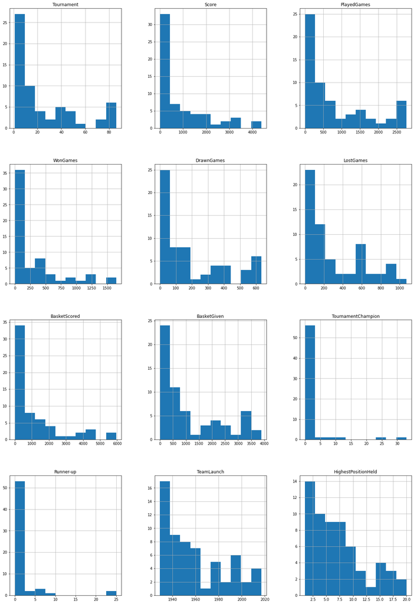

```python
data_set.hist(figsize = (20, 30))
```

### Considering that all values are integers except for team name, univariate analysis will not yield much insight

```
0    1647
1    1581
2    1241
3    1187
4    1209
Name: WonGames, dtype: int64
56    8
57    7
58    7
59    5
60    0
Name: WonGames, dtype: int64
```

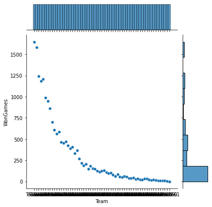

```python
print(data_set["WonGames"].head(5))
print(data_set["WonGames"].tail(5))

sns.jointplot(x = data_set["Team"], y = data_set["WonGames"])
```

## Again, a very large number of matched have been won by a few teams only The top 5 won 1000+ matches, while the bottom 5 won less than 10 matches

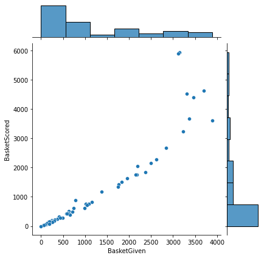

```python
sns.jointplot(x = data_set["BasketGiven"], y = data_set["BasketScored"])
```

## Nearly completely linear correlation between given opportunities and successes. Is the previous conclusion that there is great skill disparity between teams wrong?????

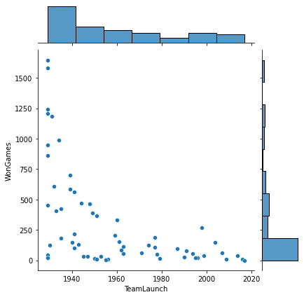

```python
sns.jointplot(x = data_set["TeamLaunch"], y = data_set["WonGames"])
```

## Teams that launched earlier win much much more matches than those that launched later. Does this mean that teams that launched ealier are better?

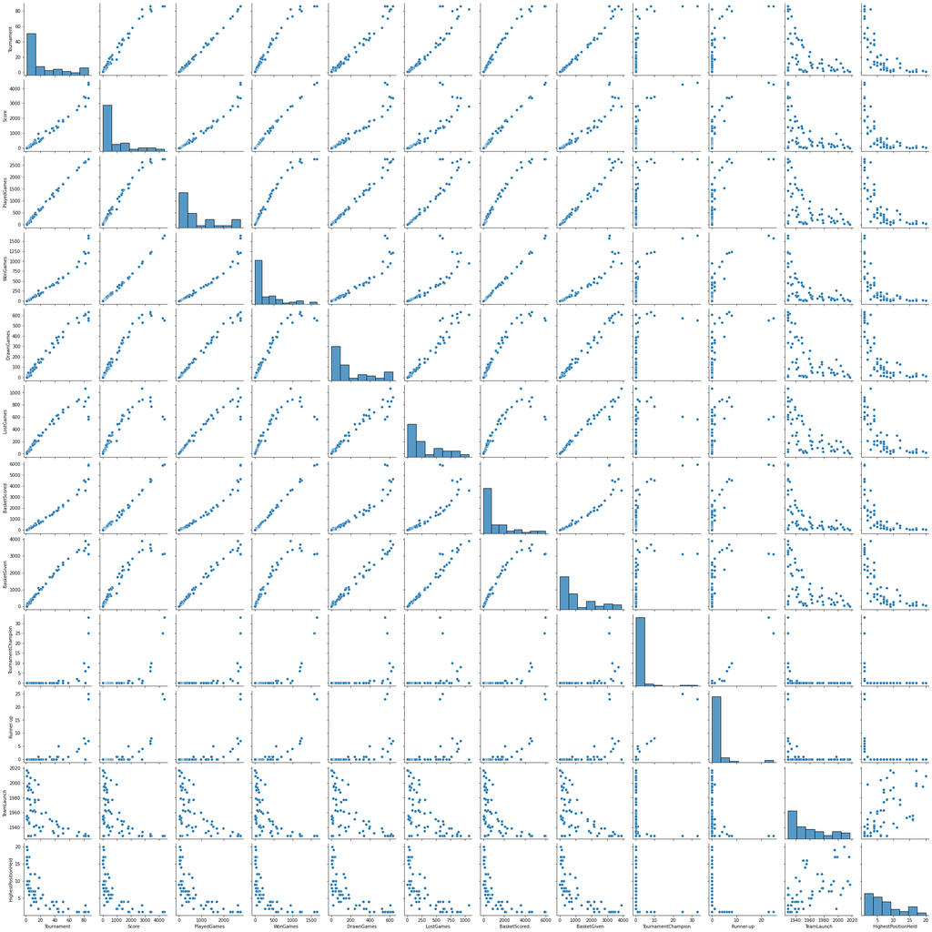

```python
%matplotlib inline
sns.pairplot(data_set);
```

## Practically all fields that can be reasonably compared either have a nearly linear correlation, or a negative non-linear correlation

- Earlier the team begins, the more matches they play, greater the acuumulated experience, hence, greater victories in matches and tournaments

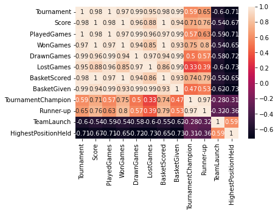

```python
correl = data_set.corr()
sns.heatmap(correl, annot=True);
```

## The heatmap proves the claims further. The lower the value of TeamLaunch, the greater the chances of winning tournaments, games, scoring baskets

- The more games a team loses, the more it wins games as well, as indicated by the 0.85 correlation b/w the two
- The number of tournaments seems to decreasing at a very high rate as time passes. there is a -0.6 correlation between TeamLaunch and Tournaments, meaning that teams simply aren't even able participate enough to even get the experience needed to compete with the older teams.

# Essentially, try to select a team that has formed as early as possible, that strongly dominates over all other factors. No team created after 1942 has won a single tournament, so it is strongly advised to select a team that was created before that year.

## **3.** Please include any improvements or suggestions to the association management on quality,

## quantity, variety, velocity, veracity etc. on the data points collected by the association to

## perform a better data analysis in future. At-least 1 suggestion for each point. [10 Marks]

## The data set seems to be completely skewed in favour of the older teams.

## There is a very large variety of data, ie, the time interval of the data is very large, nearly 90 years, that is a very good thing

## The number of teams is also large, further speaking to the variety of the dataset

## The new teams aren't able to play more matches owing to fewer tournaments being held as time passes, this help tilt the balance in favour of the older teams

# The fact that no team created after 1942 has been able to win a **single** tournament is very suspicious, it is suggested that the relevant authorities look into the authenticity of the tournaments being held, as there seems to be more than meets the eye here.

# **Part 3**

## **Domain:** Startup ecosystem

## **Context:** CONTEXT: Company X is a EU online publisher focusing on the startups industry. The

## company specifically reports on the business related to technology news, analysis of emerging trends

## and profiling of new tech businesses and products. Their event i.e. Startup Battlefield is the world’s

## pre-eminent startup competition. Startup Battlefield features 15-30 top early stage startups pitching

## top judges in front of a vast live audience, present in person and online.

## **Data Description:** CompanyX_EU.csv - Each row in the dataset is a Start-up company and the

columns describe the company.

## **Data Dictionary:**

1. Startup: Name of the company
2. Product: Actual product
3. Funding: Funds raised by the company in USD
4. Event: The event the company participated in
5. Result: Described by Contestant, Finalist, Audience choice, Winner or Runner up
6. OperatingState: Current status of the company, Operating ,Closed, Acquired or IPO

## **Project Objective:** Analyse the data of the various companies from the given dataset and perform the

## tasks that are specified in the below steps. Draw insights from the various attributes that are present in

## the dataset, plot distributions, state hypotheses and draw conclusions from the dataset.

## **Steps and Tasks:**

**Read the CSV file.**

```python
import pandas as pd
data = pd.read_csv("DS+-+Part3+-+CompanyX_EU.csv")
```

## Data exploration: [1 Mark]

## ○ Check the datatypes of each attribute.

```python
data.info()
```

```
<class 'pandas.core.frame.DataFrame'>
RangeIndex: 662 entries, 0 to 661
Data columns (total 6 columns):
 #   Column          Non-Null Count  Dtype
---  ------          --------------  -----
 0   Startup         662 non-null    object
 1   Product         656 non-null    object
 2   Funding         448 non-null    object
 3   Event           662 non-null    object
 4   Result          662 non-null    object
 5   OperatingState  662 non-null    object
dtypes: object(6)
memory usage: 31.2+ KB
```

## ○ Check for null values in the attributes.

```python
data.isnull()
```

|  | Startup | Product | Funding | Event | Result | OperatingState |
| --- | --- | --- | --- | --- | --- | --- |
| 0 | False | False | True | False | False | False |
| 1 | False | False | False | False | False | False |
| 2 | False | False | True | False | False | False |
| 3 | False | False | False | False | False | False |
| 4 | False | False | True | False | False | False |
| ... | ... | ... | ... | ... | ... | ... |
| 657 | False | False | False | False | False | False |
| 658 | False | False | False | False | False | False |
| 659 | False | False | False | False | False | False |
| 660 | False | False | False | False | False | False |
| 661 | False | False | False | False | False | False |

662 rows × 6 columns

## Data preprocessing & visualisation:

## ○ Drop the null values. [1 Mark]

```python
data = data.dropna()
data.info()
```

```
<class 'pandas.core.frame.DataFrame'>
Int64Index: 446 entries, 1 to 661
Data columns (total 6 columns):
 #   Column          Non-Null Count  Dtype
---  ------          --------------  -----
 0   Startup         446 non-null    object
 1   Product         446 non-null    object
 2   Funding         446 non-null    object
 3   Event           446 non-null    object
 4   Result          446 non-null    object
 5   OperatingState  446 non-null    object
dtypes: object(6)
memory usage: 24.4+ KB
```

## ○ Convert the ‘Funding’ features to a numerical value.

```python
cleaned_list = []
for item in data["Funding"]:
    item = str(item)
    if "K" in item:
        cleaned_list.append( float( item.replace("$", "").replace("K", "")) / 1000)
    elif "M" in item:
        cleaned_list.append( float( item.replace("$", "").replace("M", "")) )
    else:
        cleaned_list.append( float( item.replace("$", "").replace("B", "")) * 1000)

data["Funding"] = cleaned_list
```

```python
data.head()
```

|  | Startup | Product | Funding | Event | Result | OperatingState |
| --- | --- | --- | --- | --- | --- | --- |
| 1 | 3DLT | 3dlt.com | 0.63 | Disrupt NYC 2013 | Contestant | Closed |
| 3 | 3Dprintler | 3dprintler.com | 1.00 | Disrupt NY 2016 | Audience choice | Operating |
| 5 | 5to1 | 5to1.com | 19.30 | TC50 2009 | Contestant | Acquired |
| 6 | 8 Securities | 8securities.com | 29.00 | Disrupt Beijing 2011 | Finalist | Operating |
| 10 | AdhereTech | adheretech.com | 1.80 | Hardware Battlefield 2014 | Contestant | Operating |

## Plot box plot for funds in million. [1 Mark]

[figure not shown]

```python
import seaborn as sns
sns.boxplot(x="Funding", y="Startup", data=data)
```

## Is the above really what is required? It's borderline incomprehensible to me...

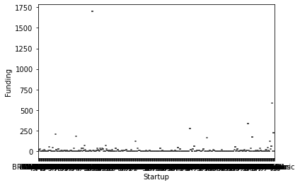

```python
sns.boxplot(x="Startup", y="Funding", data=data)
```

## The other way round doesn't look very useful either...

## Check the number of outliers greater than the upper fence. [1 Mark]

```python
q3_Funding = np.quantile(data["Funding"], 0.75)
upper_fence = 1.5 * q3_Funding
    #print(upper_fence)



outlier_list = [x for x in  data["Funding"] if x > upper_fence]
print(upper_fence)
print(len(outlier_list))
```

```
14.212499999999999
81
```

## Check frequency of the OperatingState features classes. [1 Mark]

```python
data["OperatingState"].value_counts()
```

```
Operating    319
Acquired      66
Closed        57
Ipo            4
Name: OperatingState, dtype: int64
```

## Statistical Analysis:

## Is there any significant difference between Funds raised by companies that are still

## operating vs companies that closed down? [1 Mark]

```
Q3 8.25
Q1 0.7455
IQR: 7.5045
```

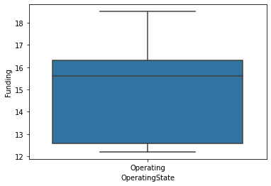

```python
#sns.boxplot(x="OperatingState", y="Funding", data=data) # useless

Operating = data.loc[data["OperatingState"] == "Operating"]
Closed = data.loc[data["OperatingState"] == "Closed"]

q3_operating = np.quantile(Operating["Funding"], 0.75)
q1_operating = np.quantile(Operating["Funding"], 0.25)

IQR_oper = q3_operating - q1_operating
outlier_free_operating = Operating.loc[Operating["Funding"] < 1.5 * IQR_oper + q3_operating ]#and Operating["Funding"] > q1_operating + 1.5*IQR_oper]
outlier_free_operating = Operating.loc[Operating["Funding"] > q1_operating + 1.5*IQR_oper]

print("Q3", q3_operating, "\nQ1", q1_operating, "\nIQR:",IQR_oper)
sns.boxplot(x="OperatingState", y="Funding", data=outlier_free_operating.loc[outlier_free_operating["Funding"] < 1.5*IQR_oper + q3_operating])
```

```
Q3 3.5
Q1 0.475
IQR: 3.025
```

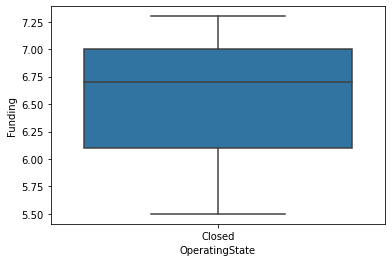

```python
q3_closed = np.quantile(Closed["Funding"], 0.75)
q1_closed = np.quantile(Closed["Funding"], 0.25)
IQR_closed = q3_closed - q1_closed

print("Q3", q3_closed, "\nQ1", q1_closed, "\nIQR:",IQR_closed)

outlier_free_closed = Closed.loc[Closed["Funding"] < 1.5 * IQR_closed + q3_closed ]#and Operating["Funding"] > q1_operating + 1.5*IQR_oper]
outlier_free_closed = Closed.loc[Closed["Funding"] > q1_closed + 1.5*IQR_closed]


sns.boxplot(x="OperatingState", y="Funding", data=outlier_free_closed.loc[outlier_free_closed["Funding"] < 1.5*IQR_closed + q3_closed])
```

## Make a copy of the original data frame. [1 Mark]

```python
copy = data.copy()
copy
```

|  | Startup | Product | Funding | Event | Result | OperatingState |
| --- | --- | --- | --- | --- | --- | --- |
| 1 | 3DLT | 3dlt.com | 0.63 | Disrupt NYC 2013 | Contestant | Closed |
| 3 | 3Dprintler | 3dprintler.com | 1.00 | Disrupt NY 2016 | Audience choice | Operating |
| 5 | 5to1 | 5to1.com | 19.30 | TC50 2009 | Contestant | Acquired |
| 6 | 8 Securities | 8securities.com | 29.00 | Disrupt Beijing 2011 | Finalist | Operating |
| 10 | AdhereTech | adheretech.com | 1.80 | Hardware Battlefield 2014 | Contestant | Operating |
| ... | ... | ... | ... | ... | ... | ... |
| 657 | Zivity | zivity.com | 8.00 | TC40 2007 | Contestant | Operating |
| 658 | Zmorph | zmorph3d.com | 1.00 | - | Audience choice | Operating |
| 659 | Zocdoc | zocdoc.com | 223.00 | TC40 2007 | Contestant | Operating |
| 660 | Zula | zulaapp.com | 3.40 | Disrupt SF 2013 | Audience choice | Operating |
| 661 | Zumper | zumper.com | 31.50 | Disrupt SF 2012 | Finalist | Operating |

446 rows × 6 columns

## Check frequency distribution of Result variables. [1 Mark]

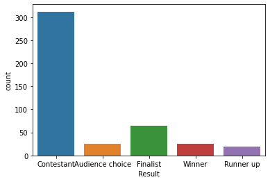

```python
sns.countplot(x= "Result", data=data)
```

## Calculate percentage of winners that are still operating and percentage of contestants

## that are still operating [1 Mark]

```python
temp = pd.read_csv("DS+-+Part3+-+CompanyX_EU.csv")

temp = temp.loc[temp["Result"] == "Winner" ] #and (data["OperatingState"] == "Operating")]) / int(data.count())
temp = temp.loc[temp["OperatingState"] == "Operating"]
print(round(len(temp)/len(data),4) * 100)
#print(len(data))
```

```
4.26
```

```python
temp = pd.read_csv("DS+-+Part3+-+CompanyX_EU.csv")

temp = temp.loc[temp["Result"] == "Contestant" ] #and (data["OperatingState"] == "Operating")]) / int(data.count())
temp = temp.loc[temp["OperatingState"] == "Operating"]
print(round(len(temp)/len(data),4) * 100)
#print(len(data))
```

```
74.44
```

## Select only the Event that has ‘disrupt’ keyword from 2013 onwards. [1 Mark]

```python
import pandas as pd
temp = pd.read_csv("DS+-+Part3+-+CompanyX_EU.csv")


final_list = []
"""
final_list = []
for record in temp:
    print(record[3])
    if record[3][0:8] == "Disrupt":
        if int(record[3][-4:]) >= 2013:
            final_list.append(record)
print(final_list)
"""
for index in range(0, len(temp)):
    if  "Disrupt" in str(temp["Event"][index]):
        if "201" in str(temp["Event"][index]):
            if 3 <= int(str(temp["Event"][index])[-1]):
                print(temp["Event"][index])
```

```
Disrupt SF 2013
Disrupt NYC 2013
Disrupt SF 2016
Disrupt NY 2016
Disrupt NYC 2013
Disrupt SF 2015
Disrupt London 2016
Disrupt SF 2015
Disrupt NYC 2014
Disrupt London 2016
Disrupt SF 2014
Disrupt SF 2016
Disrupt SF 2016
Disrupt SF 2013
Disrupt NYC 2013
Disrupt NY 2015
Disrupt SF 2015
Disrupt NY 2016
Disrupt EU 2013
Disrupt SF 2014
Disrupt SF 2015
Disrupt NY 2016
Disrupt NY 2016
Disrupt SF 2014
Disrupt SF 2013
Disrupt NY 2016
Disrupt NYC 2013
Disrupt NY 2015
Disrupt NY 2016
Disrupt SF 2013
Disrupt NY 2015
Disrupt SF 2016
Disrupt NYC 2014
Disrupt NY 2016
Disrupt SF 2013
Disrupt SF 2015
Disrupt SF 2013
Disrupt SF 2016
Disrupt SF 2016
Disrupt EU 2014
```

[output cut: 221 more lines]

```
Disrupt EU 2013
Disrupt NY 2016
Disrupt SF 2016
Disrupt SF 2016
Disrupt NY 2015
Disrupt SF 2015
Disrupt NY 2015
Disrupt EU 2013
Disrupt NYC 2013
Disrupt SF 2014
Disrupt London 2015
Disrupt London 2015
Disrupt EU 2014
Disrupt NYC 2013
Disrupt SF 2013
```